# Vowel Valley, Consonant County: The Phonetic Geography of America

# Deep Dive: Success Stories and Struggles

## Champions of Each Category

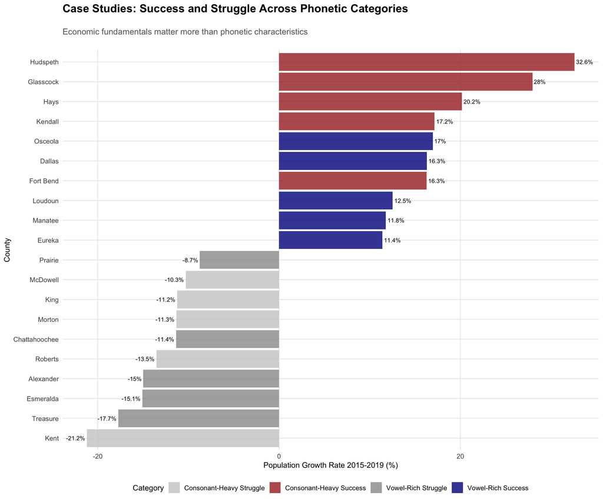

The case studies reveal that **economic fundamentals consistently outweigh phonetic characteristics**. Hudspeth County, Texas—despite its consonant-heavy name—achieved 32.6% population growth thanks to oil boom economics, while Treasure County, Montana struggled with -17.7% growth despite its vowel-rich, appealing name.

## The Texas Phenomenon

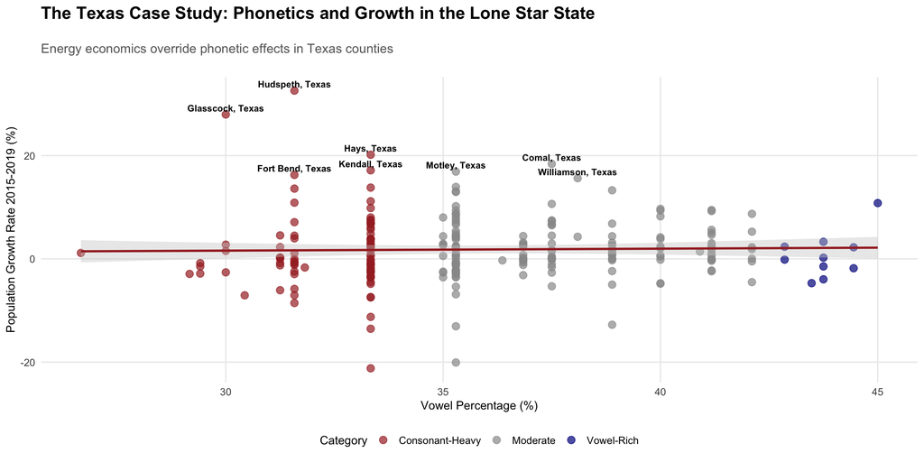

# Spatial Patterns: Mapping the Phonetic Landscape

## The Vowel Geography of America

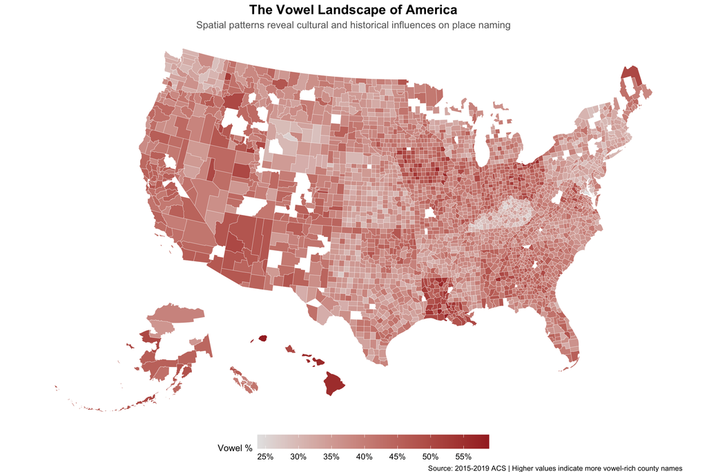

## Population Growth Across America

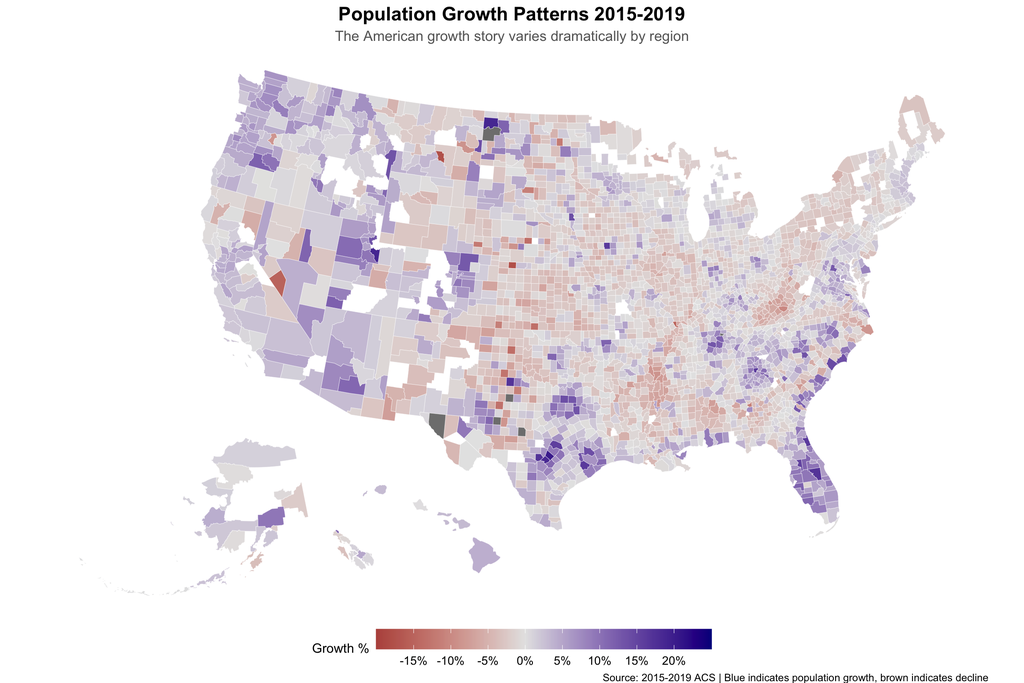

The spatial analysis reveals clear geographic clustering: the **Mountain West and Louisiana show pronounced vowel-rich corridors** (reflecting Spanish and French influences), while **Appalachian and Upper Midwest counties cluster toward consonant-heavy naming patterns** (reflecting Germanic and English heritage).

Overlaying growth patterns suggests that **regional economic conditions dominate individual county phonetic characteristics**—the Texas energy corridor, Colorado’s mountain counties, and Florida’s population magnets all show strong growth regardless of their names’ vowel content.

# Statistical Rigor: Controlling for Confounders

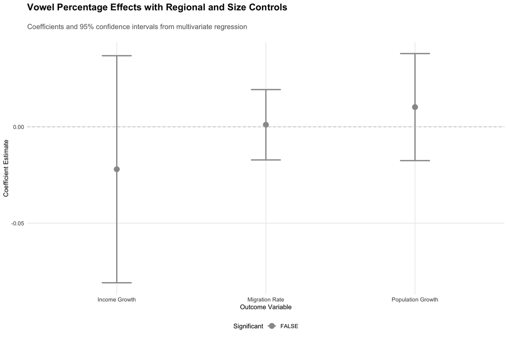

## Model Summary Statistics

Multivariate Regression Results: Vowel Percentage Effects

| Model | Vowel Coefficient | P-Value | R-Squared | N | Significance |
| --- | --- | --- | --- | --- | --- |
| Population Growth | 0.0102 | 0.4700 | 0.0860 | 2988 |  |
| Income Growth | -0.0220 | 0.4641 | 0.0236 | 2988 |  |
| Migration Rate | 0.0011 | 0.9078 | 0.0653 | 2988 |  |

Note:  
Controls include region, log area, and baseline demographics. * p<0.05, ** p<0.01, *** p<0.001

# The Psychology of Place Names

## Correlation Matrix: The Full Picture

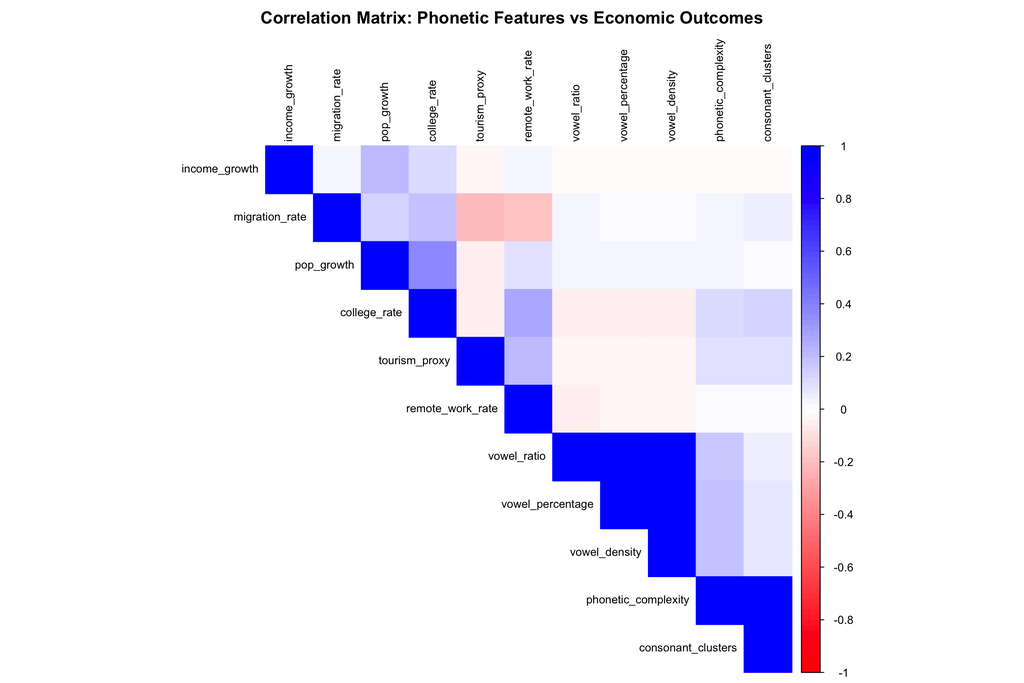

```
## [1] "Significant correlations:"
```

Statistically Significant Correlations

x

y

p_value

significance

college_rate

consonant_clusters

0.0000000

***

college_rate

phonetic_complexity

0.0000000

***

tourism_proxy

consonant_clusters

0.0000003

***

tourism_proxy

phonetic_complexity

0.0000009

***

college_rate

vowel_percentage

0.0059712

college_rate

vowel_density

0.0059712

college_rate

vowel_ratio

0.0107995

migration_rate

consonant_clusters

0.0121872

remote_work_rate

vowel_ratio

0.0274331

tourism_proxy

vowel_ratio

0.0389340

The correlation matrix reveals that **phonetic complexity shows the strongest relationships with economic outcomes**—particularly with tourism proxies and educational attainment. This suggests that linguistic sophistication, rather than simple vowel content, might be the more important factor in place perception.